# Data Analysis and Machine Learning

## Loading Dataset

Here, we are going to look at the dataset “players.csv”, which contains the per game stats of a players from the last 10 seasons, ie. from 2014-15 season to 2023-24 season.

```r
players <- read.csv("players.csv")
str(players)
```

```
## 'data.frame':    6070 obs. of  31 variables:
##  $ Season                           : chr  "2014-15" "2014-15" "2014-15" "2014-15" ...
##  $ Team                             : chr  "Atlanta Hawks" "Atlanta Hawks" "Atlanta Hawks" "Atlanta Hawks" ...
##  $ Player                           : chr  "Paul Millsap" "Kyle Korver" "DeMarre Carroll" "Al Horford" ...
##  $ Age                              : int  29 33 28 28 26 21 30 25 32 26 ...
##  $ Position                         : chr  "PF" "SG" "SF" "C" ...
##  $ Games                            : int  73 75 70 76 73 77 52 75 63 68 ...
##  $ Games_Started                    : int  73 75 69 76 72 10 7 10 3 0 ...
##  $ Minutes_Played                   : num  32.7 32.2 31.3 30.5 30.5 19.7 18.8 17.7 16.5 16.5 ...
##  $ Field_Goals                      : num  6.1 3.9 4.5 6.8 5.6 3.7 2 1.9 1.7 3 ...
##  $ Field_Goal_Attempts              : num  12.7 8 9.3 12.7 12.2 8.6 4.8 4.4 4.7 6.7 ...
##  $ Field_Goal_Percentage            : num  0.476 0.487 0.487 0.538 0.46 0.427 0.418 0.426 0.365 0.444 ...
##  $ Three_Point_Field_Goals          : num  1.1 2.9 1.7 0.1 1 0.7 0.5 0.6 0.8 1 ...
##  $ Three_Point_Field_Goal_Attempts  : num  3 6 4.3 0.5 2.8 1.9 1.5 1.8 2.7 2.8 ...
##  $ Three_Point_Field_Goal_Percentage: num  0.356 0.492 0.395 0.306 0.343 0.351 0.321 0.364 0.301 0.344 ...
```

[output cut: 17 more lines]

Dataset has 6070 rows, and 31 columns.

Data types:

- Season: ordinal categorical variable
- Team: nominal categorical variable
- Player: nominal categorical variable
- Age: continuous numerical variable
- Position: nominal categorical variable
- Games: continuous numerical data
- Games_Started: continuous numerical data
- Minutes_Played: continuous numerical data
- Field_Goals: continuous numerical data
- Field_Goal_Attempts: continuous numerical data
- Field_Goal_Percentage: continuous numerical data
- Three_Point_Field_Goals: continuous numerical data
- Three_Point_Field_Goal_Attempts: continuous numerical data
- Three_Point_Field_Goal_Percentage: continuous numerical data
- Two_Point_Field_Goals: continuous numerical data
- Two_Point_Field_Goal_Attempts: continuous numerical data
- Two_Point_Field_Goal_Percentage: continuous numerical data
- Effective_Field_Goal_Percentage: continuous numerical data
- Free_Throws: continuous numerical data
- Free_Throw_Attempts: continuous numerical data
- Free_Throw_Percentage: continuous numerical data
- Offensive_Rebounds: continuous numerical data
- Defensive_Rebounds: continuous numerical data
- Total_Rebounds: continuous numerical data
- Assists: continuous numerical data
- Steals: continuous numerical data
- Blocks: continuous numerical data
- Turnovers: continuous numerical data
- Personal_Fouls: continuous numerical data
- Points: continuous numerical data
- All_Star: nominal categorical data

Since some players played for more than one team in a season, they appear multiple times in the dataset with same Season but different Team. Therefore, we group together the players that played for more than one team in a season.

```r
library(dplyr)
players <- players %>%
  group_by(Season, Player, Age, All_Star) %>%
  summarise(
    Team = paste(Team, collapse = ", "),
    Position = ifelse(n_distinct(Position) > 1, paste(unique(Position), collapse = ", "), unique(Position)),
    Games_Started = sum(Games_Started),
    Minutes_Played = round(sum(Minutes_Played * Games) / sum(Games), 1),
    Field_Goals = round(sum(Field_Goals * Games) / sum(Games), 1),
    Field_Goal_Attempts = round(sum(Field_Goal_Attempts * Games) / sum(Games), 1),
    Field_Goal_Percentage = round(sum(Field_Goal_Percentage * Games) / sum(Games), 3),
    Three_Point_Field_Goals = round(sum(Three_Point_Field_Goals * Games) / sum(Games), 1),
    Three_Point_Field_Goal_Attempts = round(sum(Three_Point_Field_Goal_Attempts * Games) / sum(Games), 1),
    Three_Point_Field_Goal_Percentage = round(sum(Three_Point_Field_Goal_Percentage * Games) / sum(Games), 3),
    Two_Point_Field_Goals = round(sum(Two_Point_Field_Goals * Games) / sum(Games), 1),
    Two_Point_Field_Goal_Attempts = round(sum(Two_Point_Field_Goal_Attempts * Games) / sum(Games), 1),
    Two_Point_Field_Goal_Percentage = round(sum(Two_Point_Field_Goal_Percentage * Games) / sum(Games), 3),
    Effective_Field_Goal_Percentage = round(sum(Effective_Field_Goal_Percentage * Games) / sum(Games), 3),
    Free_Throws = round(sum(Free_Throws * Games) / sum(Games), 1),
    Free_Throw_Attempts = round(sum(Free_Throw_Attempts * Games) / sum(Games), 1),
    Free_Throw_Percentage = round(sum(Free_Throw_Percentage * Games) / sum(Games), 3),
    Offensive_Rebounds = round(sum(Offensive_Rebounds * Games) / sum(Games), 1),
    Defensive_Rebounds = round(sum(Defensive_Rebounds * Games) / sum(Games), 1),
    Total_Rebounds = round(sum(Total_Rebounds * Games) / sum(Games), 1),
    Assists = round(sum(Assists * Games) / sum(Games), 1),
    Steals = round(sum(Steals * Games) / sum(Games), 1),
    Blocks = round(sum(Blocks * Games) / sum(Games), 1),
    Turnovers = round(sum(Turnovers * Games) / sum(Games), 1),
    Personal_Fouls = round(sum(Personal_Fouls * Games) / sum(Games), 1),
    Points = round(sum(Points * Games) / sum(Games), 1),
    Games = sum(Games),
    .groups = "drop"
  )
```

```r
str(players)
```

```
## tibble [5,309 × 31] (S3: tbl_df/tbl/data.frame)
##  $ Season                           : chr [1:5309] "2014-15" "2014-15" "2014-15" "2014-15" ...
##  $ Player                           : chr [1:5309] "A.J. Price" "Aaron Brooks" "Aaron Gordon" "Adreian Payne" ...
##  $ Age                              : int [1:5309] 28 30 19 23 28 30 24 32 23 23 ...
##  $ All_Star                         : int [1:5309] 0 0 0 0 1 0 0 0 0 0 ...
##  $ Team                             : chr [1:5309] "Cleveland Caveliers, Indiana Pacers, Pheonix Suns" "Chicago Bulls" "Orlando Magic" "Atlanta Hawks, Minnesota Timberwolves" ...
##  $ Position                         : chr [1:5309] "PG" "PG" "PF" "PF" ...
##  $ Games_Started                    : int [1:5309] 0 21 8 22 76 61 3 19 27 0 ...
##  $ Minutes_Played                   : num [1:5309] 12.5 23 17 23.1 30.5 30.6 18.5 23.6 33.3 2.8 ...
##  $ Field_Goals                      : num [1:5309] 2 4.2 2 2.9 6.8 7.5 2 2.6 4.5 0.2 ...
##  $ Field_Goal_Attempts              : num [1:5309] 5.3 10 4.4 6.8 12.7 15.5 4.8 5.9 11.1 0.8 ...
##  $ Field_Goal_Percentage            : num [1:5309] 0.322 0.421 0.447 0.406 0.538 0.481 0.412 0.443 0.403 0.25 ...
##  $ Three_Point_Field_Goals          : num [1:5309] 0.6 1.5 0.3 0 0.1 0 0.5 1 1 0 ...
##  $ Three_Point_Field_Goal_Attempts  : num [1:5309] 2.2 3.8 1 0.3 0.5 0.1 1.7 2.8 2.5 0 ...
##  $ Three_Point_Field_Goal_Percentage: num [1:5309] 0.148 0.387 0.271 0.113 0.306 0.4 0.274 0.348 0.382 0 ...
```

[output cut: 17 more lines]

Now, we can see the rows reduced to 5309.

## Exploratory Data Analysis

In this project, we will focus on whether all-star players have better stats overall as compared to non all-star players. We will also try to predict whether a player has all-star level production based on their stats.

Therefore, the dependent variable is All_Star.

The research question is: Given a players stats per game, will the player will make the all-star team?

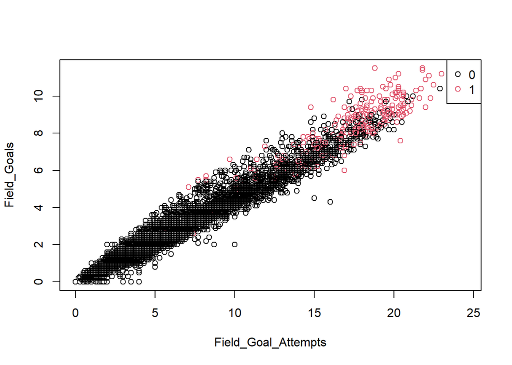

```r
plot(Field_Goals ~ Field_Goal_Attempts, col = All_Star + 1, data = players)
legend("topright", legend = unique(players$All_Star), col = unique(players$All_Star) + 1, pch = 1)
```

There is a strong positive relationship between Field_Goal_Attempts and Field_Goals. As players attempt more field goals per game, more field goals per game are made. All-star players generally attempt and make more field goals per game than non all-star players.

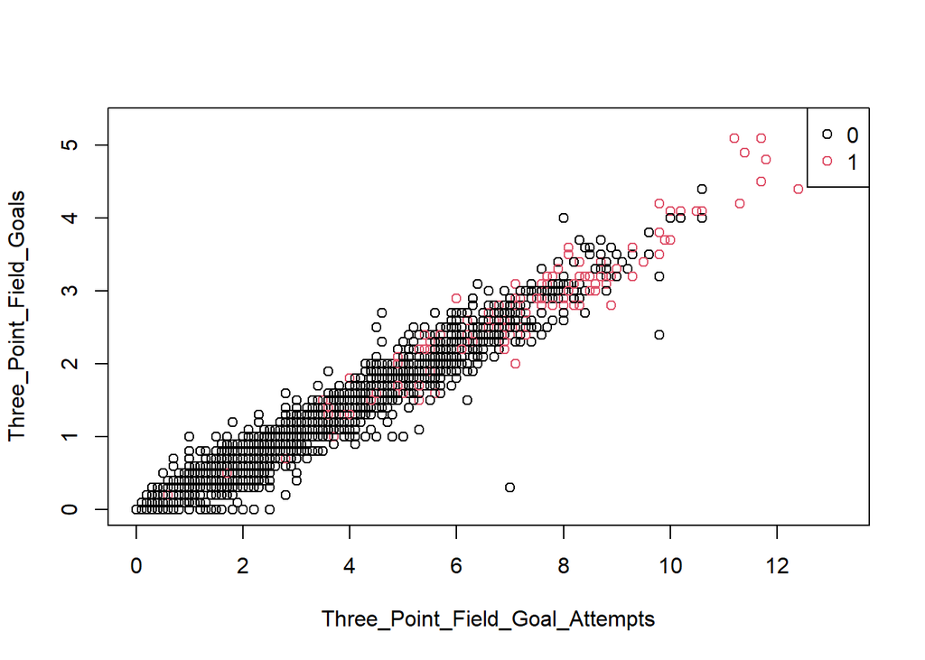

```r
plot(Three_Point_Field_Goals ~ Three_Point_Field_Goal_Attempts, col = All_Star + 1, data = players)
legend("topright", legend = unique(players$All_Star), col = unique(players$All_Star) + 1, pch = 1)
```

There is a strong positive relationship between Three_Point_Field_Goal_Attempts and Three_Point_Field_Goals. As players attempt more three pointers per game, more three pointers per game are made. All-star players generally attempt and make more three pointers per game than non all-star players.

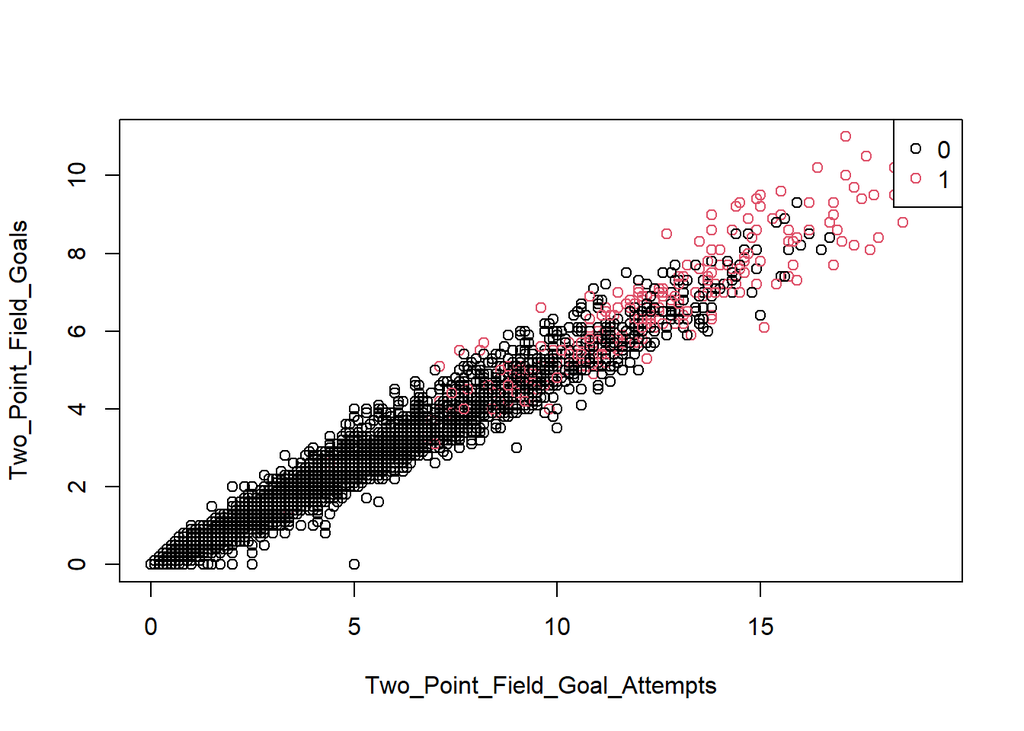

```r
plot(Two_Point_Field_Goals ~ Two_Point_Field_Goal_Attempts, col = All_Star + 1, data = players)
legend("topright", legend = unique(players$All_Star), col = unique(players$All_Star) + 1, pch = 1)
```

There is a strong positive relationship between Two_Point_Field_Goal_Attempts and Two_Point_Field_Goals. As players attempt more two pointers per game, more two pointers per game are made. All-star players generally attempt and make more two pointers per game than non all-star players.

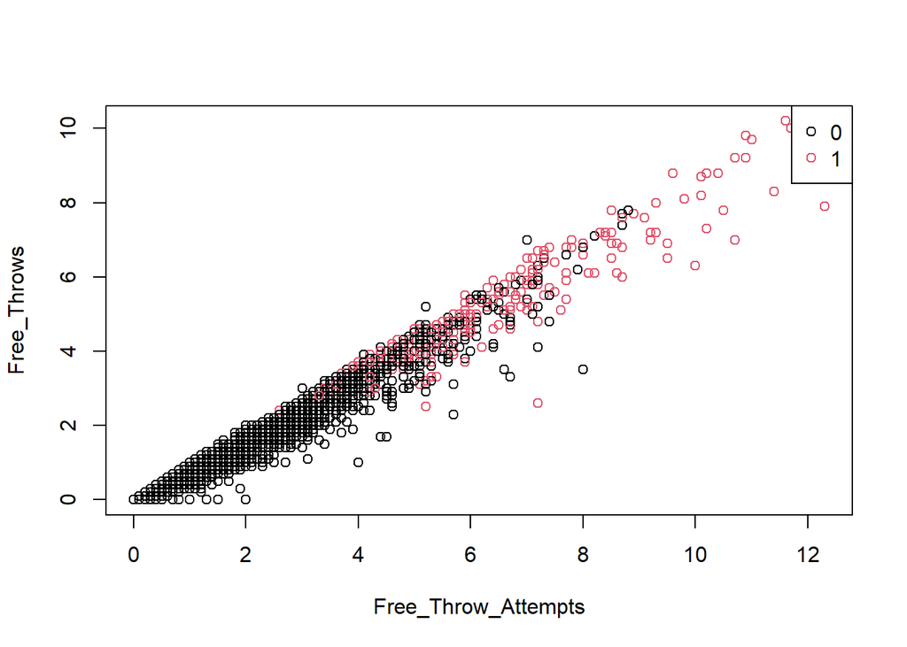

```r
plot(Free_Throws ~ Free_Throw_Attempts, col = All_Star + 1, data = players)
legend("topright", legend = unique(players$All_Star), col = unique(players$All_Star) + 1, pch = 1)
```

There is a strong positive relationship between Free_Throw_Attempts and Free_Throws. As players attempt more free throws per game, more free throws per game are made. All-star players generally attempt and make more free throws per game than non all-star players.

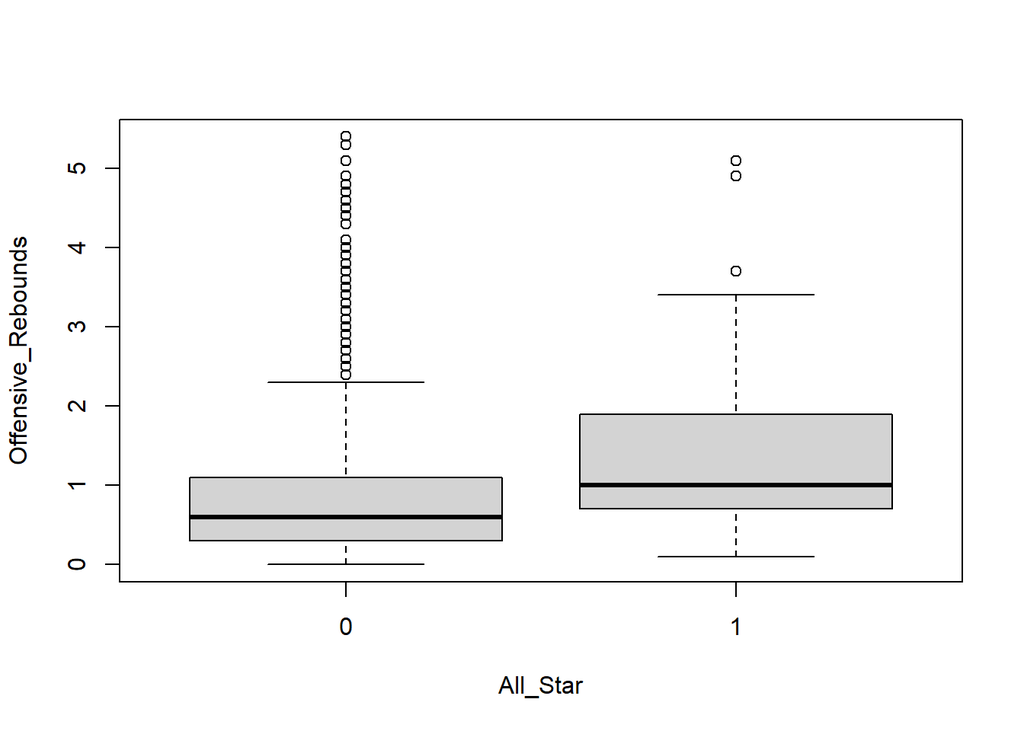

```r
boxplot(Offensive_Rebounds ~ All_Star, data = players)
```

All-star players have more offensive rebounds per game as compared to non all-star players.

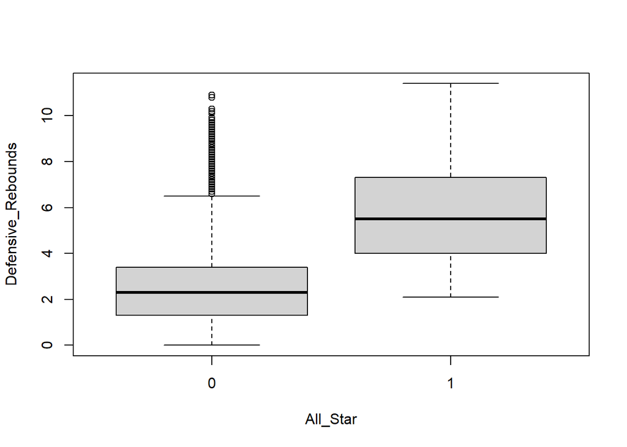

```r
boxplot(Defensive_Rebounds ~ All_Star, data = players)
```

All-star players have more defensive rebounds per game as compared to non all-star players.

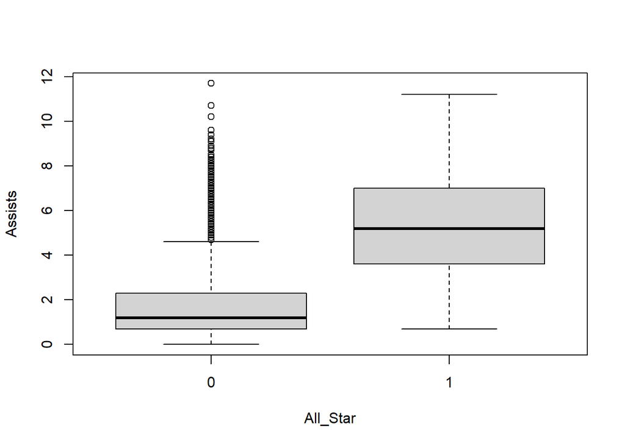

```r
boxplot(Assists ~ All_Star, data = players)
```

All-star players have more assists per game as compared to non all-star players.

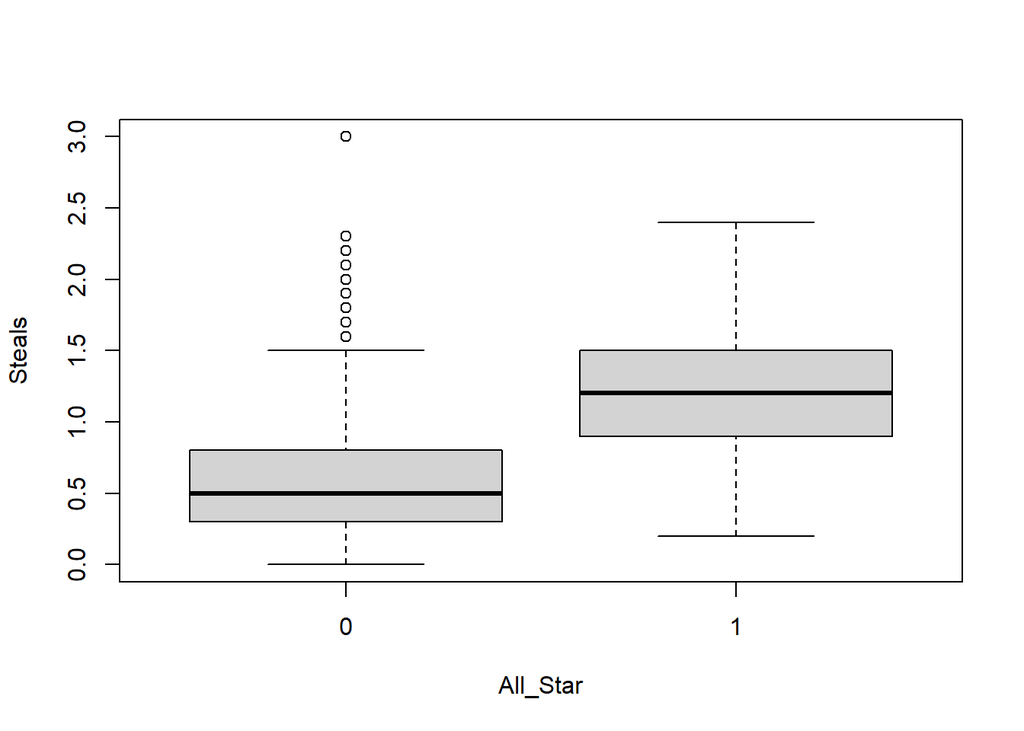

```r
boxplot(Steals ~ All_Star, data = players)
```

All-star players have more steals per game as compared to non all-star players.

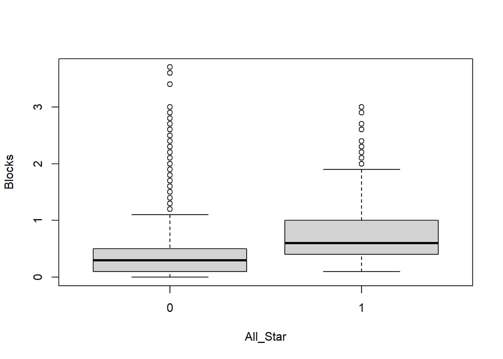

```r
boxplot(Blocks ~ All_Star, data = players)
```

All-star players have more blocks per game as compared to non all-star players.

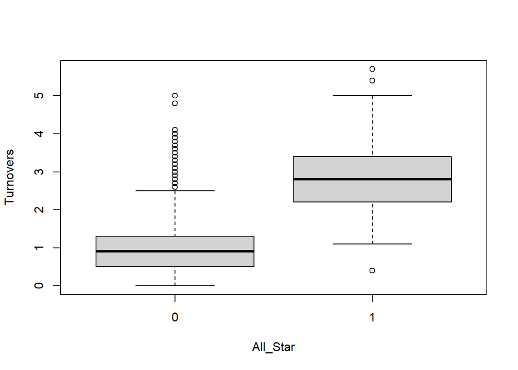

```r
boxplot(Turnovers ~ All_Star, data = players)
```

All-star players have more turnovers per game as compared to non all-star players.

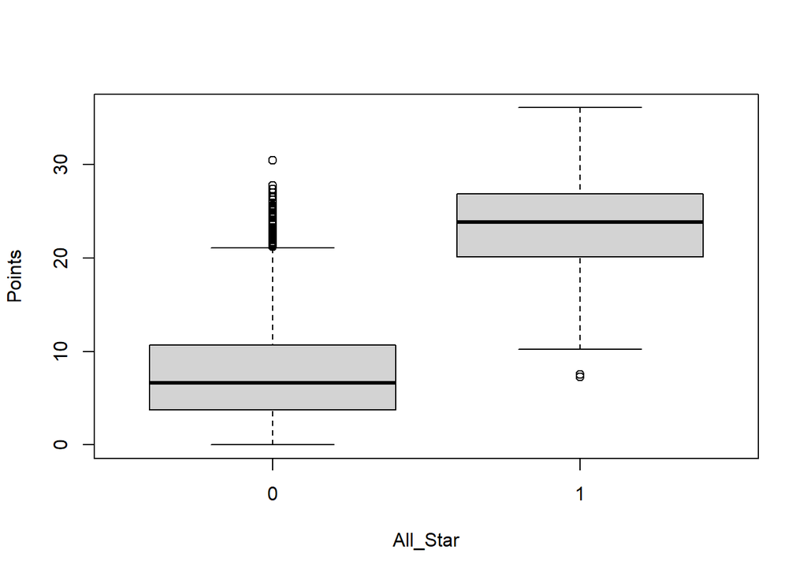

```r
boxplot(Points ~ All_Star, data = players)
```

All-star players have more points per game as compared to non all-star players.

## Machine Learning

Now, for machine learning, we first remove variables that are not relevant in predicting whether a player will make the all-star team, and also variables that might have multicollinearity.

```r
players2 <- subset(players, select = -c(Season, Player, Age, Team, Position, Games, Games_Started, Minutes_Played, Field_Goals, Field_Goal_Attempts, Field_Goal_Percentage, Three_Point_Field_Goal_Attempts, Two_Point_Field_Goal_Attempts, Free_Throw_Attempts, Effective_Field_Goal_Percentage, Total_Rebounds, Personal_Fouls, Points))
```

Reasons for removing the columns:

- Season, Player, Age, Team, Games, Games_Started, Minutes_Played, Personal_Fouls: Not relevant in predicting whether a player will make the all-star team
- Field_Goals: Might have multicollinearity with Three_Point_Field_Goals and Two_Point_Field_Goals as Field_Goals = Three_Point_Field_Goals + Two_Point_Field_Goals
- Field_Goal_Attempts: Might have multicollinearity with Three_Point_Field_Goal_Attempt and Two_Point_Field_Goal_Attempt as Field_Goals = Three_Point_Field_Goal_Attempt + Two_Point_Field_Goal_Attempt
- Field_Goal_Percentage: Might have multicollinearity with Three_Point_Field_Goal_Percentage and Two_Point_Field_Goal_Percentage
- Three_Point_Field_Goal_Attempts: Might have multicollinearity with Three_Point_Field_Goals and Three_Point_Field_Goal_Percentage as Three_Point_Field_Goal_Percentage = Three_Point_Field_Goals/Three_Point_Field_Goal_Attempts
- Two_Point_Field_Goal_Attempts: Might have multicollinearity with Two_Point_Field_Goals and Two_Point_Field_Goal_Percentage as Two_Point_Field_Goal_Percentage = Two_Point_Field_Goals/Two_Point_Field_Goal_Attempts
- Free_Throw_Attempts: Might have multicollinearity with Free_Throws and Free_Throw_Percentage as Free_Throw_Percentage = Free_Throws/Free_Throw_Attempts
- Effective_Field_Goal_Percentage: Might have multicollinearity with Two_Point_Field_Goals, Three_Point_Field_Goals and Field_Goal_Attempts as Effective_Field_Goal_Percentage = (Two_Point_Field_Goals + 1.5 * Three_Point_Field_Goals)/Field_Goal_Attempts
- Points: Might have multicollinearity with Two_Point_Field_Goals, Three_Point_Field_Goals and Free_Throws as Points = Two_Point_Field_Goals * 2 + Three_Point_Field_Goals * 3 + Free Throws

Next, we split the dataset into train and test sets. (80% and 20%)

```r
train <- players2[1:4247,]
test <- players2[4248:5309,]
```

And we choose the model. Since the dependent variable (All_Star) is a categorical variable, and the output is binary (0 or 1), logistic regression is a good model for predicting whether a player will make the all-star team.

```r
model <- glm(All_Star ~ Three_Point_Field_Goals +
             Three_Point_Field_Goal_Percentage + Two_Point_Field_Goals +
             Two_Point_Field_Goal_Percentage + Free_Throws + Free_Throw_Percentage +
             Offensive_Rebounds + Defensive_Rebounds + Assists + Steals + Blocks +
             Turnovers,
             family=binomial(link='logit'),data=train)

summary(model)
```

```
##
## Call:
## glm(formula = All_Star ~ Three_Point_Field_Goals + Three_Point_Field_Goal_Percentage +
##     Two_Point_Field_Goals + Two_Point_Field_Goal_Percentage +
##     Free_Throws + Free_Throw_Percentage + Offensive_Rebounds +
##     Defensive_Rebounds + Assists + Steals + Blocks + Turnovers,
##     family = binomial(link = "logit"), data = train)
##
## Coefficients:
##                                    Estimate Std. Error z value Pr(>|z|)
## (Intercept)                       -12.90405    2.06467  -6.250 4.11e-10 ***
## Three_Point_Field_Goals             1.00391    0.17336   5.791 7.01e-09 ***
## Three_Point_Field_Goal_Percentage  -0.27842    1.53023  -0.182  0.85562
## Two_Point_Field_Goals               0.65061    0.10223   6.364 1.97e-10 ***
## Two_Point_Field_Goal_Percentage    -0.30603    2.66771  -0.115  0.90867
## Free_Throws                         0.49496    0.10846   4.564 5.03e-06 ***
## Free_Throw_Percentage               0.89288    1.78028   0.502  0.61599
## Offensive_Rebounds                 -0.36393    0.24887  -1.462  0.14365
## Defensive_Rebounds                  0.54588    0.09610   5.680 1.34e-08 ***
## Assists                             0.40682    0.09026   4.507 6.57e-06 ***
## Steals                              1.24247    0.31337   3.965 7.34e-05 ***
## Blocks                              0.79973    0.27890   2.867  0.00414 **
## Turnovers                          -0.69968    0.26613  -2.629  0.00856 **
## ---
## Signif. codes:  0 '***' 0.001 '**' 0.01 '*' 0.05 '.' 0.1 ' ' 1
##
## (Dispersion parameter for binomial family taken to be 1)
##
##     Null deviance: 1701.76  on 4246  degrees of freedom
## Residual deviance:  561.38  on 4234  degrees of freedom
## AIC: 587.38
##
## Number of Fisher Scoring iterations: 9
```

Based on the summary, Three_Point_Field_Goal_Percentage, Two_Point_Field_Goal_Percentage, Free_Throw_Percentage, Offensive_Rebounds are not significant, therefore we can remove them.

```r
players3 <- subset(players, select = -c(Season, Player, Age, Team, Position, Games, Games_Started, Minutes_Played, Field_Goals, Field_Goal_Attempts, Field_Goal_Percentage, Three_Point_Field_Goal_Attempts, Three_Point_Field_Goal_Percentage, Two_Point_Field_Goal_Attempts, Two_Point_Field_Goal_Percentage, Free_Throw_Attempts, Free_Throw_Percentage, Effective_Field_Goal_Percentage, Total_Rebounds, Offensive_Rebounds, Personal_Fouls, Points))

train2 <- players3[1:4247,]
test2 <- players3[4248:5309,]

model2 <- glm(All_Star ~ Three_Point_Field_Goals + Two_Point_Field_Goals + Free_Throws +
              Defensive_Rebounds + Assists + Steals + Blocks + Turnovers,
              family=binomial(link='logit'),data=train)

summary(model2)
```

```
##
## Call:
## glm(formula = All_Star ~ Three_Point_Field_Goals + Two_Point_Field_Goals +
##     Free_Throws + Defensive_Rebounds + Assists + Steals + Blocks +
##     Turnovers, family = binomial(link = "logit"), data = train)
##
## Coefficients:
##                          Estimate Std. Error z value Pr(>|z|)
## (Intercept)             -12.49783    0.74820 -16.704  < 2e-16 ***
## Three_Point_Field_Goals   1.10489    0.14178   7.793 6.55e-15 ***
## Two_Point_Field_Goals     0.61750    0.09644   6.403 1.53e-10 ***
## Free_Throws               0.53817    0.09981   5.392 6.96e-08 ***
## Defensive_Rebounds        0.44923    0.07532   5.965 2.45e-09 ***
## Assists                   0.44310    0.08594   5.156 2.52e-07 ***
## Steals                    1.17519    0.30768   3.820 0.000134 ***
## Blocks                    0.70130    0.27003   2.597 0.009402 **
## Turnovers                -0.73760    0.25038  -2.946 0.003220 **
## ---
## Signif. codes:  0 '***' 0.001 '**' 0.01 '*' 0.05 '.' 0.1 ' ' 1
##
## (Dispersion parameter for binomial family taken to be 1)
##
##     Null deviance: 1701.76  on 4246  degrees of freedom
## Residual deviance:  564.44  on 4238  degrees of freedom
## AIC: 582.44
##
## Number of Fisher Scoring iterations: 9
```

Now, every variables are significant.

```r
library(car)
vif(model2)
```

```
## Three_Point_Field_Goals   Two_Point_Field_Goals             Free_Throws
##                1.686276                1.887148                1.674766
##      Defensive_Rebounds                 Assists                  Steals
##                1.936060                2.944662                1.317091
##                  Blocks               Turnovers
##                1.954219                2.866267
```

After checking VIF, there is no multicollinearity.

Now, we evaluate the model.

```r
fitted.results <- predict(model2,newdata=subset(test2,select=c(2:9)),type='response')
fitted.results <- ifelse(fitted.results > 0.5,1,0)

misClasificError <- mean(fitted.results != test2$All_Star)
print(paste('Accuracy',1-misClasificError))
```

```
## [1] "Accuracy 0.976459510357815"
```

The model has high accuracy, which is good.

```r
library(caret)
confusionMatrix <- confusionMatrix(factor(fitted.results), factor(test2$All_Star))
print(confusionMatrix)
```

```
## Confusion Matrix and Statistics
##
##           Reference
## Prediction   0   1
##          0 991   5
##          1  20  46
##
##                Accuracy : 0.9765
##                  95% CI : (0.9654, 0.9847)
##     No Information Rate : 0.952
##     P-Value [Acc > NIR] : 3.018e-05
##
##                   Kappa : 0.7741
##
##  Mcnemar's Test P-Value : 0.00511
##
##             Sensitivity : 0.9802
##             Specificity : 0.9020
##          Pos Pred Value : 0.9950
##          Neg Pred Value : 0.6970
##              Prevalence : 0.9520
##          Detection Rate : 0.9331
##    Detection Prevalence : 0.9379
##       Balanced Accuracy : 0.9411
##
##        'Positive' Class : 0
##
```

```r
precision <- confusionMatrix$byClass["Precision"]
recall <- confusionMatrix$byClass["Recall"]
f1_score <- 2 * ((precision * recall) / (precision + recall))
print(paste("Precision:", precision))
```

```
## [1] "Precision: 0.994979919678715"
```

```r
print(paste("Recall:", recall))
```

```
## [1] "Recall: 0.980217606330366"
```

```r
print(paste("F1 Score:", f1_score))
```

```
## [1] "F1 Score: 0.987543597409068"
```

The model also has pretty high F1 score, which is also good.

```r
fitted.probabilities <- predict(model2, newdata=subset(test2, select=c(2:9)), type='response')
actual <- test2$All_Star
predicted <- fitted.probabilities

log_loss <- -mean(actual * log(predicted) + (1 - actual) * log(1 - predicted))
print(paste("Log-Loss:", log_loss))
```

```
## [1] "Log-Loss: 0.0605779257393959"
```

Moreover, the model has low log loss.

Now, we try to predict whether a player makes the all-star team. Below is the stats of Michael Jordan in 1988, and he did made the all-star team during that season. Let’s see if our model can correctly predict.

```r
new_data <- data.frame(
  Three_Point_Field_Goals = 0.1,
  Two_Point_Field_Goals = 13.0,
  Free_Throws = 8.8,
  Defensive_Rebounds = 3.8,
  Assists = 5.9,
  Steals = 3.2,
  Blocks = 1.6,
  Turnovers = 3.1
)
ifelse(predict(model2,newdata=new_data,type='response') > 0.5, "Yes", "No")
```

```
##     1
## "Yes"
```